# Snow Data Assignment: Web Scraping, Functions, and Iteration

Anna Marshall

09 February, 2022

# Overview

Understanding the seasonal delivery and distribution of mountain snow cover, snowpack, and seasonal trends is important to the American West and to snowmelt-watered regions everywhere.The Center for Snow and Avalanche Studies established and operates the Senator Beck Basin Study Area as a purpose-built mountain system observatory in an alpine headwater catchment of the Uncompahgre River at Red Mountain Pass, in the western San Juan Mountains of southwest Colorado. Senator Beck Basin is located in a critically wet and cold portion of the Colorado River Basin.

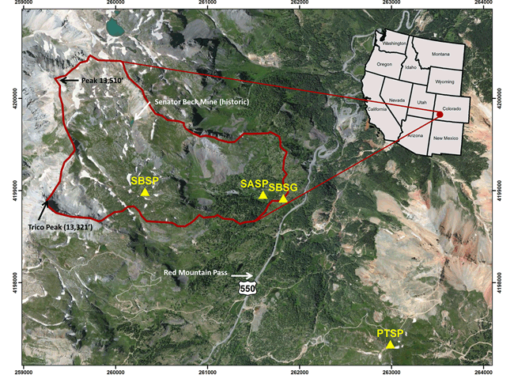

In the assignment below, I’ll work through manipulating some of the precipitation and temperature data collected as part of the long term Mountain System Monitoring.

# Methods

This analysis uses the `SASP forcing` and `SBSP_forcing` meteorological data sets to understand how temperature and precipitation patterns change with time at the two sites.

# Analysis and Discussion

## Q1

### Extract the meteorological data URLs. Here we want you to use the `rvest` package to get the URLs for the `SASP forcing` and `SBSP_forcing` meteorological datasets.

```r
site_url <- 'https://snowstudies.org/archived-data/'

#Read the web url
webpage <- read_html(site_url)

#Extract only weblinks and then the URLs!
links <- webpage %>%
  html_nodes('a') %>% #a indicates a link to something
  .[grepl('forcing',.)] %>%
  html_attr('href')
links
```

```
## [1] "https://snowstudies.org/wp-content/uploads/2022/02/SBB_SASP_Forcing_Data.txt"
## [2] "https://snowstudies.org/wp-content/uploads/2022/02/SBB_SBSP_Forcing_Data.txt"
```

## Q2

### Download the meteorological data. Use the `download_file` and `str_split_fixed` commands to download the data and save it in your data folder.

Downloaded data in a for loop

```r
#Grab only the name of the file by splitting out on forward slashes
splits <- str_split_fixed(links,'/',8)
splits
```

```
##      [,1]     [,2] [,3]              [,4]         [,5]      [,6]   [,7]
## [1,] "https:" ""   "snowstudies.org" "wp-content" "uploads" "2022" "02"
## [2,] "https:" ""   "snowstudies.org" "wp-content" "uploads" "2022" "02"
##      [,8]
## [1,] "SBB_SASP_Forcing_Data.txt"
## [2,] "SBB_SBSP_Forcing_Data.txt"
```

```r
#Keep only the 8th column
dataset <- splits[,8] %>%
  gsub('.txt','',.)

#generate a file list for where the data goes
file_names <- paste0('data/',dataset)
datapath = 'data/'
dir.create(datapath)
file_names <- paste0(datapath,dataset)

for(i in 1:2){
  download.file(links[i],destfile=file_names[i])
}

downloaded <- file.exists(file_names)

evaluate <- !all(downloaded)
```

### Downloaded data in a map

```r
#Map version of the same for loop (downloading 3 files)
if(evaluate == T){
  map2(links[1:2],file_names[1:2],download.file)
}else{print('data already downloaded')}
```

```
## [1] "data already downloaded"
```

```r
library(pdftools)
headers <- pdf_text('https://snowstudies.org/wp-content/uploads/2022/02/Serially-Complete-Metadata-text08.pdf') %>%
  readr::read_lines(.) %>%
  trimws(.) %>%
  str_split_fixed(.,'\\.',2) %>%
  .[,2] %>%
  #.[1:14] %>%
  str_trim(side = "left")
```

## Q3

### Writing a custom function to read in the data and append a site column to the data.

Below is code for creating a for loop to read in the data. Note the function is included in Q4 where I use map to read in the data and append a site column.

```r
#Pattern matching to only keep certain files
weather_files <- file_names %>%
  .[!grepl('24hr',.)]

empty_data <- list()
weather_data <- for(i in 1:length(weather_files)){
  empty_data[[i]] <- read_table(file_names[i],col_names=headers)
    read_table(weather_files[i])

}
str(empty_data)
   # select(Year,DOY,Sno_Height_M)
weather_data_full <- do.call('rbind',empty_data) %>%
    select(year,month,day,"precip [kg m-2 s-1]","air temp [K]")
    #mutate(site = name)
#summary(weather_data_full)
```

## Q4

### As a map function with tibble displayed

```r
#Pattern matching to only keep certain files
file=weather_files[1]
weather_data_map<- function(file){
  name=str_split_fixed(file,'/',2)[,2]%>%
    gsub('Forcing_Data.txt','',.)
  df<-read_table(file,col_names=headers,skip=4) %>%
    select(c(1,2,3,7,10)) %>%
    mutate(site=name)
}

weather_data_full <- map_dfr(weather_files,weather_data_map)
summary(weather_data_full)
```

```
##       year          month             day        precip [kg m-2 s-1]
##  Min.   :2003   Min.   : 1.000   Min.   : 1.00   Min.   :0.000e+00
##  1st Qu.:2005   1st Qu.: 3.000   1st Qu.: 8.00   1st Qu.:0.000e+00
##  Median :2007   Median : 6.000   Median :16.00   Median :0.000e+00
##  Mean   :2007   Mean   : 6.472   Mean   :15.76   Mean   :3.838e-05
##  3rd Qu.:2009   3rd Qu.: 9.000   3rd Qu.:23.00   3rd Qu.:0.000e+00
##  Max.   :2011   Max.   :12.000   Max.   :31.00   Max.   :6.111e-03
##   air temp [K]       site
##  Min.   :242.1   Length:138336
##  1st Qu.:265.8   Class :character
##  Median :272.6   Mode  :character
##  Mean   :272.6
##  3rd Qu.:279.7
##  Max.   :295.8
```

## Q5

### Make a line plot of mean temp by year by site

In the plot of mean temp by year by site, we see a sharp decline in mean temperature in 2003. A difference of nearly 10 K in 2003 compared to the other years does not make sense. I expect that there was instrument error or calibration error in the data during the first year of collection, which is causing this outlier in mean annual temperatures.

```r
names(weather_data_full)[names(weather_data_full)=='air temp [K]']<-"air_temp"
temp_yearly<-weather_data_full %>%
  group_by(year,site) %>%
  summarize(mean_temp = mean(air_temp,na.rm=T))
```

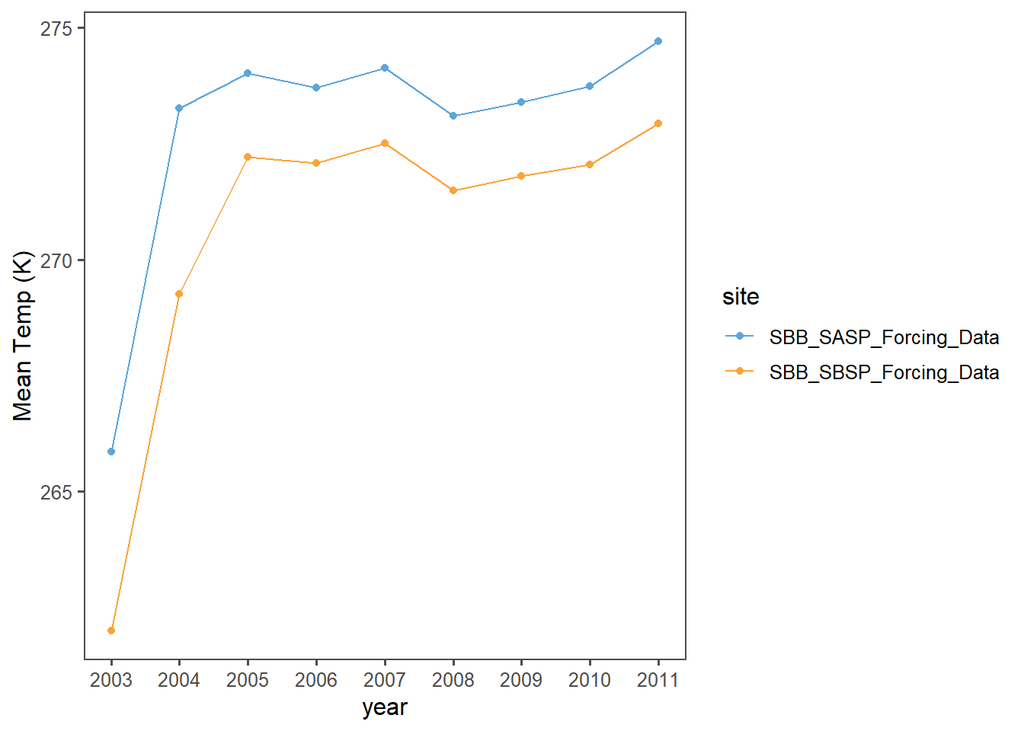

```r
ggplot(temp_yearly,aes(x=year, y=mean_temp,color=site))+
  geom_point()+
  geom_line()+
  ggthemes::theme_few()+
  ggthemes::scale_color_few()+
  ylab("Mean Temp (K)")+
  scale_x_continuous(breaks=c(2002, 2003,2004,2005,2006,2007,2008,2009,2010,2011,2012))
```

## Q6

### Write a function that makes line plots of monthly average temperature at each site for a given year. Use a for loop to make these plots for 2005 to 2010.

Monthly average temperatures are always warmer at the Swamp Angel study plot compared to the Senator Beck study plot.This makes sense given that SASP is located in a sheltered location below treeline.SBSP is located above treeline in the alpine tundrea.

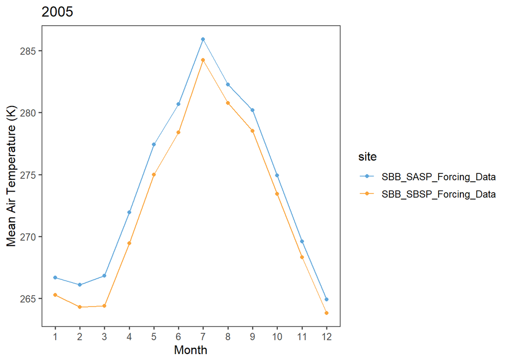

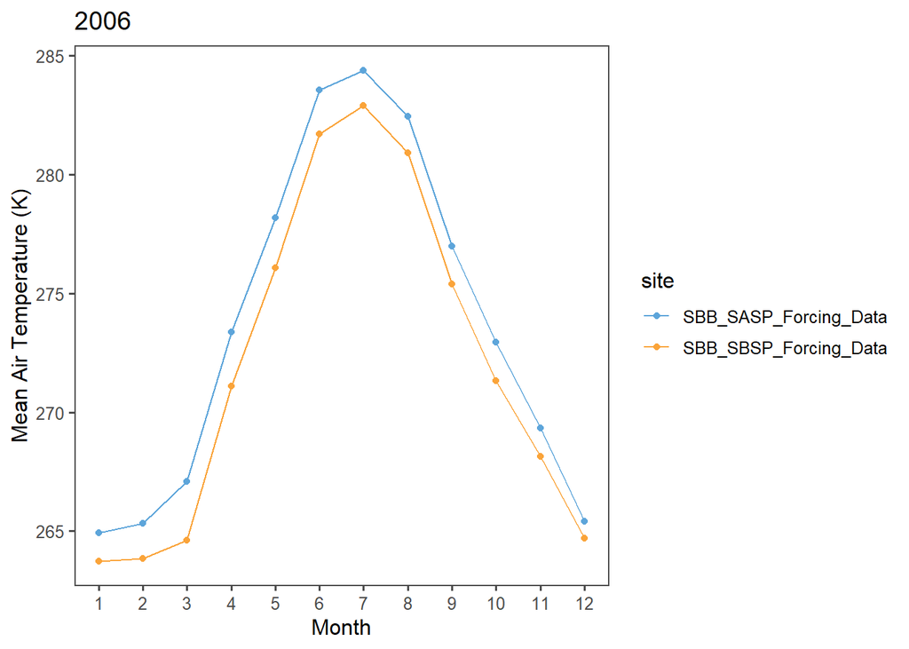

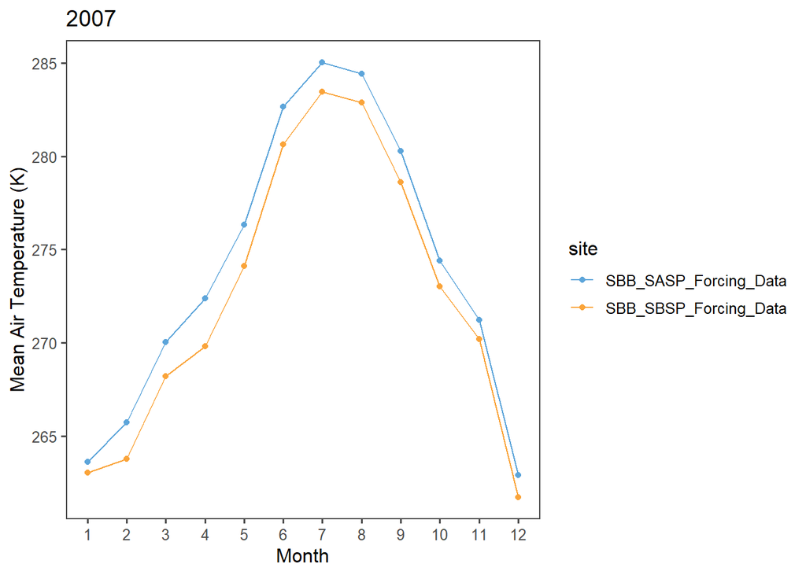

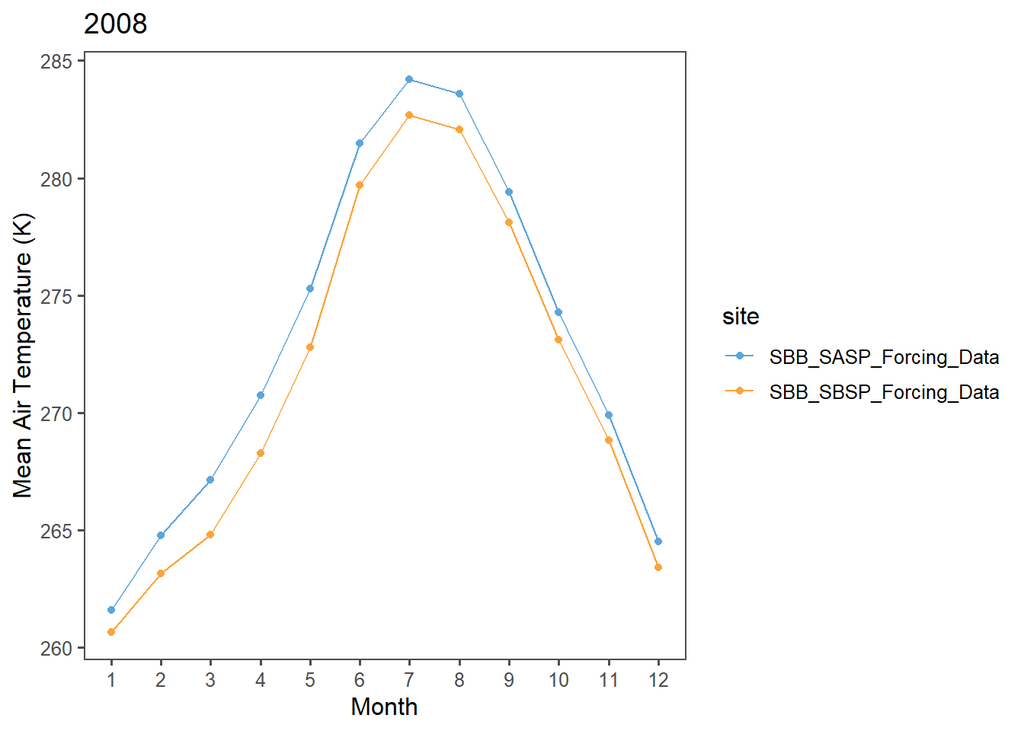

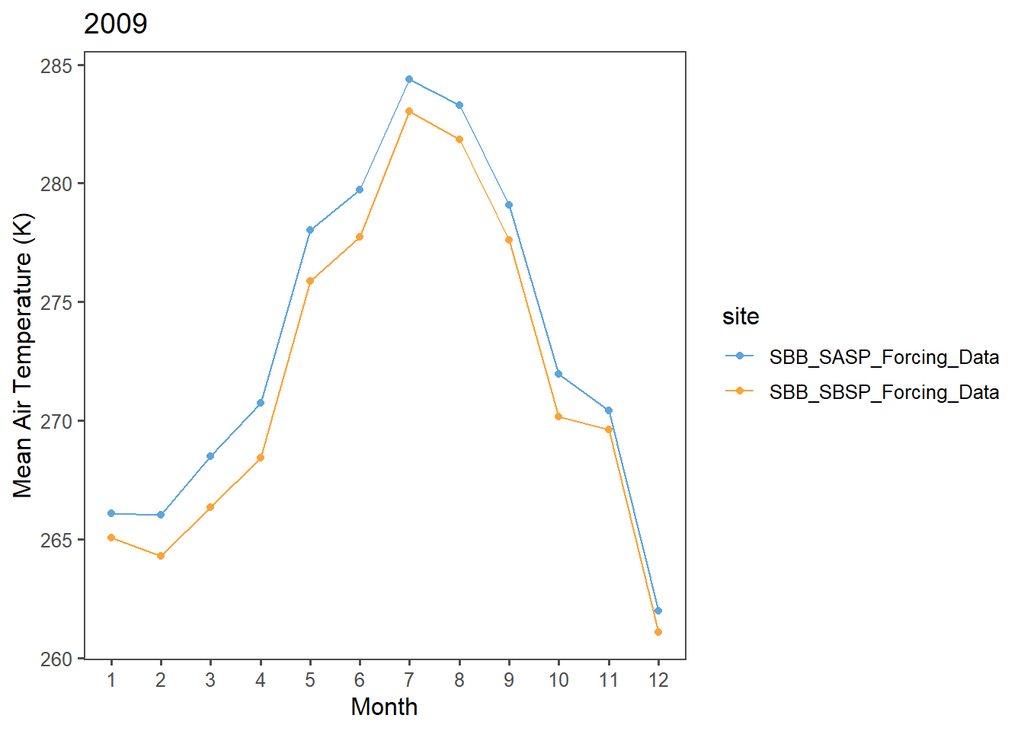

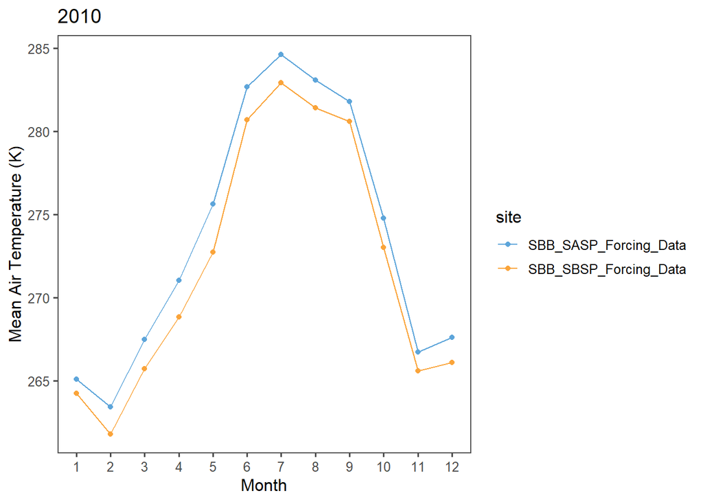

```r
names(weather_data_full)[names(weather_data_full)=='air temp [K]']<-"air_temp"
plotfunction<-function(year){
  yeardata<-weather_data_full %>% filter(year==i) %>%
    group_by(month,site) %>%
    summarise(mean_temp = mean(air_temp,na.rm=T))
  print(ggplot(yeardata,aes(x=month,y=mean_temp,color=site))+
          geom_line()+
          geom_point()+
          ggthemes::theme_few()+
          ylab("Mean Air Temperature (K)")+
          xlab("Month")+
          ggthemes::scale_color_few()+
          scale_x_continuous(breaks=c(1,2,3,4,5,6,7,8,9,10,11,12))+
          ggtitle(year))

}
for (i in 2005:2010){
  plotfunction(i)}
```

## Bonus 1

Precipitation data here was converted from kg m-2 s-1 to mm/day. However, the precipitation values are not realistic and suggest the conversion was inaccurate. Nonetheless, the general pattern can still be gleaned from these plots.

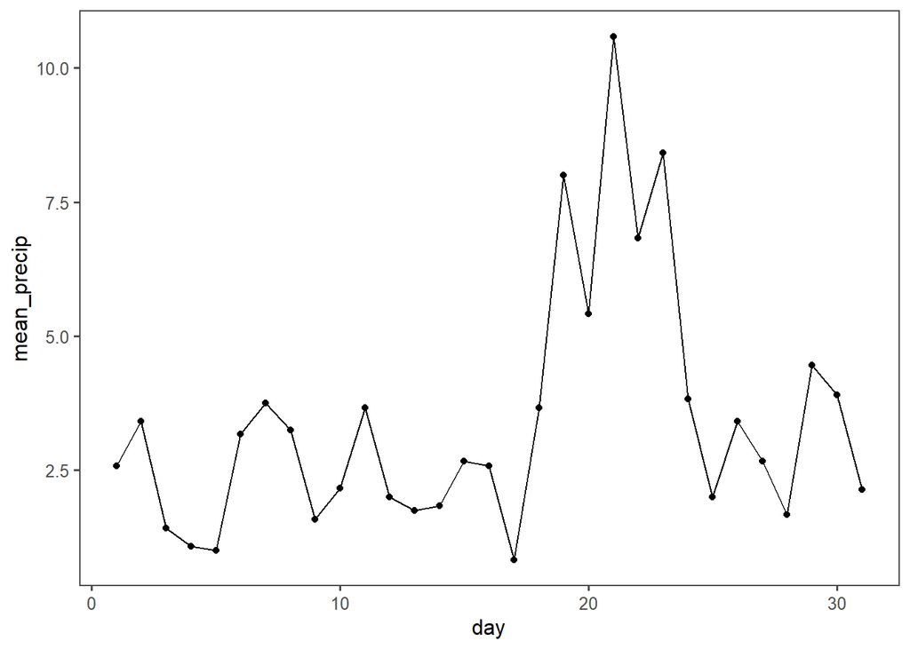

```r
names(weather_data_full)[names(weather_data_full)=='precip [kg m-2 s-1']<-"precip"
weather_data_full$`precip [kg m-2 s-1]`<-weather_data_full$`precip [kg m-2 s-1]`*86400
  precip_daily <- weather_data_full %>% filter(year==i) %>%
    group_by(day) %>%
    summarize(mean_precip = mean(`precip [kg m-2 s-1]`,na.rm=T))
ggplot(precip_daily,aes(x=day,y=mean_precip)) +
  geom_point()+
  geom_line()+
  ggthemes::theme_few()+
  ggthemes::scale_color_few()
```

## Bonus 2

[figure not shown]

[figure not shown]

[figure not shown]

[figure not shown]

[figure not shown]

[figure not shown]

```r
plotfunction<-function(year){
  yeardata2<-weather_data_full %>% filter(year==i) %>%
    group_by(day) %>%
    summarize(mean_precip = mean(`precip [kg m-2 s-1]`,na.rm=T))
  print(ggplot(yeardata2,aes(x=day,y=mean_precip))+
          geom_line()+
          geom_point()+
          ggthemes::theme_few()+
          ylab("Mean Air Temperature (K)")+
          xlab("Month")+
          ggthemes::scale_color_few()+
          ggtitle(year))

}
for (i in 2005:2010){
  plotfunction(i)}
```